# R Function

曾意儒 Yi-Ju Tseng

### 大綱

- 函數 Function
- 函式程式設計 Functional programming
- purrr package

## Why we need a function

One of the best ways to improve your reach as a data scientist is to write functions. - [R for Data Science](https://r4ds.had.co.nz/functions.html)

### Automate common tasks

- Makes your code easier to understand
- You only need to update code once, instead of many
- Reuse the codes. No more copy-and-paste. No incidental mistakes

### When we need a function

- Copy and paste a block of code multiple times
- No more copy-and-paste!

### For examples...

Caculate Length/Width ratio, round to hundredths

```r
round(iris$Sepal.Length/iris$Sepal.Width,2)
round(iris$Petal.Length/iris$Petal.Width,2)
```

```
[1] 1.46 1.63 1.47 1.48 1.39
```

```
[1] 7.0 7.0 6.5 7.5 7.0
```

Have to type **,2** multiple times

### 4 components in a function

```r
function_name <- function(arg_1, arg_2, ...) {
   Function body
    return(return_value)
}
```

- Function Name `function_name`
- Arguments, optional `arg_1, arg_2, ...`
- Function Body
- Return Value, optional `return_value`

### Common Functions in R - mean

```r
mean(1:6)
```

```
[1] 3.5
```

```r
(1+2+3+4+5+6)/6
```

```
[1] 3.5
```

```r
sum(1:6)/length(1:6)
```

```
[1] 3.5
```

### User defined functions (UDF) - myMean

Write a mean function - myMean

```r
myMean<-function(vec){
    m<-sum(vec)/length(vec)
    return(m)
}
myMean(1:6)
```

```
[1] 3.5
```

```r
myMean(2:10)
```

```
[1] 6
```

### A Cube function

```r
cube<-function(x){
    x_cube<-x*x*x
    return(x_cube)
}
cube(2)
```

```
[1] 8
```

```r
cube(4)
```

```
[1] 64
```

```r
cube(6)
```

```
[1] 216
```

### A BMI function with 2 arguments

```r
bmi<-function(height,weight){
    if(height>5){
        height <- height/100
    }
    bmi <- weight / height**2
    return(bmi)
}
bmi(160,50)
```

```
[1] 19.53125
```

```r
bmi(1.6,50)
```

```
[1] 19.53125
```

### myMean, round to hundredths

Write a mean function - myMean

```r
myMean<-function(vec){
    m<-sum(vec)/length(vec)
    return(round(m,2))
}
myMean(c(1.55,2.66,3.67))
```

```
[1] 2.63
```

```r
myMean(2:10)
```

```
[1] 6
```

### myMean, round to ?

Write a mean function - myMean

```r
myMean<-function(vec, dig){
    m<-sum(vec)/length(vec)
    return(round(m,dig))
}
myMean(c(1.55,2.66,3.67),2)
```

```
[1] 2.63
```

```r
myMean(c(1.55,2.66,3.67),3)
```

```
[1] 2.627
```

### myMean, round to ?, default 2

Write a mean function - myMean

```r
myMean<-function(vec, dig=2){
    m<-sum(vec)/length(vec)
    return(round(m,dig))
}
myMean(c(1.55,2.66,3.67))
```

```
[1] 2.63
```

```r
myMean(c(1.55,2.66,3.67),4)
```

```
[1] 2.6267
```

### Local variables vs global variables

- Local variables: in a function (including args) `vec, dig`
- Global variables: not in a function `d`

```r
d<-4
myMean<-function(vec, dig=2){
    m<-sum(vec)/length(vec)
    return(round(m,dig))
}
myMean(c(1.55,2.66,3.67))
myMean(c(1.55,2.66,3.67),d)
vec
```

[output not shown]

Error: object 'vec' not found

### References

- [R for Data Science](https://r4ds.had.co.nz/functions.html)
- [Advanced R](https://adv-r.hadley.nz/functionals.html)

## Functional programming

In computer science, functional programming is a programming paradigm that treats computation as the **evaluation of mathematical functions** and avoids changing-state and mutable data.

### Functional programming - First Class

- Assign a function to a variable
- Pass a function as an argument
- Return a function

### Assign a function to a variable

To `bmi` variable = set function name as `bmi`

```r
bmi<-function(height,weight){
    if(height>5){
        height <- height/100
    }
    bmi <- weight / height**2
    return(bmi)
}
bmi(160,50)
```

```
[1] 19.53125
```

```r
bmi(1.6,50)
```

```
[1] 19.53125
```

### Pass a function as an argument

Demo in `purrr` package

### Return a function

return `hello()` function

```r
hello<-function(){
    print("Hello")
}
sayHello <- function() {
    return(hello())
}
sayHello()
```

```
[1] "Hello"
```

## purrr package

`purrr` enhances R’s functional programming (FP) toolkit by providing a complete and consistent set of tools for working with functions and vectors.

No more `for` loop!

### map family

map(), map_chr(), map_int(), map_dbl(), map_df(), walk()

### When you need for loop

```r
good_teacher_score<-function(ori_score){
    better_score<-sqrt(ori_score)*10
    return(better_score)
}
good_teacher_score(30)
```

```
[1] 54.77226
```

```r
good_teacher_score(50)
```

```
[1] 70.71068
```

For 30 students?

### When you need for loop

```r
ori_score_list<-sample(1:100,30)
ori_score_list[1:3]
```

```
[1] 31 10 30
```

```r
good_teacher_score(ori_score_list[1])
```

```
[1] 55.67764
```

```r
good_teacher_score(ori_score_list[2])
```

```
[1] 31.62278
```

```r
#.....
```

### map family

```r
library(purrr)
new_score_list<-
    map_dbl(ori_score_list,
            good_teacher_score)
```

```r
data.frame(ori_score_list,
           new_score_list)
```

| ori_score_list | new_score_list |
| --- | --- |
| 31 | 55.67764 |
| 10 | 31.62278 |
| 30 | 54.77226 |
| 99 | 99.49874 |
| 71 | 84.26150 |
| 75 | 86.60254 |
| 55 | 74.16198 |
| 49 | 70.00000 |
| 92 | 95.91663 |
| 8 | 28.28427 |
| 48 | 69.28203 |
| 33 | 57.44563 |
| 43 | 65.57439 |
| 63 | 79.37254 |
| 76 | 87.17798 |
| 87 | 93.27379 |
| 28 | 52.91503 |
| 40 | 63.24555 |
| 67 | 81.85353 |
| 3 | 17.32051 |
| 65 | 80.62258 |
| 44 | 66.33250 |
| 85 | 92.19544 |
| 35 | 59.16080 |
| 39 | 62.44998 |
| 96 | 97.97959 |
| 100 | 100.00000 |
| 64 | 80.00000 |
| 1 | 10.00000 |
| 68 | 82.46211 |

### map2 family

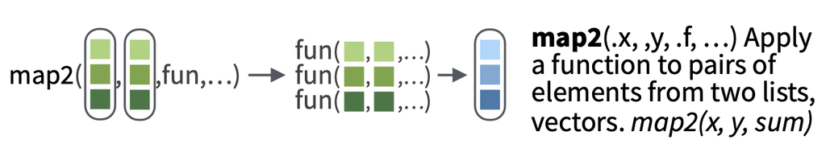

[圖片來源](https://github.com/rstudio/cheatsheets/blob/master/purrr.pdf)

### Weighted score caculation

```r
chi_score<-c(60,50,40)
eng_score<-c(60,50,40)
weight_score<-function(chi,eng){
    final_score<-chi+eng*2
    return(final_score)
}
weight_score_list<-
    map2_dbl(chi_score,
             eng_score,
            weight_score)
```

```r
data.frame(chi_score,
           eng_score,
           weight_score_list)
```

| chi_score | eng_score | weight_score_list |
| --- | --- | --- |
| 60 | 60 | 180 |
| 50 | 50 | 150 |
| 40 | 40 | 120 |

### References

- [purrr package](https://purrr.tidyverse.org/)